# Pinguins de Palmer

Um exemplo de uso do Quarto

Autor

Afiliação

Jesus M. Castagnetto, Ph.D.

INSIGHT / UPCH

**Código**

```r
# carregamos as bibliotecas que precisamos
library(tidyverse)
library(knitr)
library(palmerpenguins)  # dados
```

## Introdução

Este é um exemplo de relatório simples, em formato HTML, gerado no Quarto.

Usaremos dados de pinguins do Arquipélago Palmer (Antártica), que foram originalmente coletados pelo **Dr. Kristen Gorman**, como parte do *Programa de Pesquisa Ecológica de Longo Prazo* (LTER) da Palmer Station.

Esses dados incluem medidas anatômicas, pesos e outros parâmetros de pinguins adultos das espécies Adélie, Chinstrap e Gentoo, nas áreas próximas à Estação Palmer.

O conjunto de dados está disponível como um pacote R: [palmerpenguins](https://allisonhorst.github.io/palmerpenguins/), através dos esforços de [Allison Horst](https://www.allisonhorst.com/), [Alison Hill](https://www.apreshill.com/) e [Kristen Gorman](https://www.uaf.edu/cfos/people/faculty/detail/kristen-gorman.php). Nas seções a seguir usaremos esses dados para ilustrar a criação de uma tabela simples e alguns gráficos.

Abaixo podemos ver um resumo da estrutura de dados:

**Código**

```r
glimpse(penguins)
```

```
Rows: 344
Columns: 8
$ species           <fct> Adelie, Adelie, Adelie, Adelie, Adelie, Adelie, Adel…
$ island            <fct> Torgersen, Torgersen, Torgersen, Torgersen, Torgerse…
$ bill_length_mm    <dbl> 39.1, 39.5, 40.3, NA, 36.7, 39.3, 38.9, 39.2, 34.1, …
$ bill_depth_mm     <dbl> 18.7, 17.4, 18.0, NA, 19.3, 20.6, 17.8, 19.6, 18.1, …
$ flipper_length_mm <int> 181, 186, 195, NA, 193, 190, 181, 195, 193, 190, 186…
$ body_mass_g       <int> 3750, 3800, 3250, NA, 3450, 3650, 3625, 4675, 3475, …
$ sex               <fct> male, female, female, NA, female, male, female, male…
$ year              <int> 2007, 2007, 2007, 2007, 2007, 2007, 2007, 2007, 2007…
```

Esses dados têm 8 colunas e 344 registros de pinguins, que foram encontrados em 3 ilhas: Biscoe, Dream, Torgersen

## Estatísticas de pinguins por espécie e sexo

Vamos criar algumas tabelas resumindo os dados que temos sobre os pinguins, para os quais calcularemos, para cada combinação de espécie e sexo, o número total de indivíduos registados, o número de ilhas em que aparecem, bem como as médias e desvios padrão de: comprimento do bico e nadadeira, profundidade do bico e peso dos pinguins.

**Código**

```r
esp_sexo <- penguins %>%
  group_by(
    species,
    sex
  ) %>%
  summarise(
    total = n(),
    n_islas = n_distinct(island),
    prom_long_pico = mean(bill_length_mm, na.rm = TRUE),
    sd_long_pico = sd(bill_length_mm, na.rm = TRUE),
    prom_prof_pico = mean(bill_depth_mm, na.rm = TRUE),
    sd_prof_pico = sd(bill_depth_mm, na.rm = TRUE),
    prom_long_ala = mean(flipper_length_mm, na.rm = TRUE),
    sd_long_ala = sd(flipper_length_mm, na.rm = TRUE),
    prom_peso = mean(body_mass_g, na.rm = TRUE),
    sd_peso = sd(body_mass_g, na.rm = TRUE)
  ) %>%
  ungroup() %>%
  mutate(  # Muda o conteúdo para portuguese
    sex = case_when(
        sex == "male" ~ "Masculino",
        sex == "female" ~ "Femenino",
        is.na(sex) ~ "Desconhecido"
      )
  )
```

Os dados agregados, vamos organizá-los de forma que possamos criar algumas tabelas:

1. A primeira, mostrando para cada combinação de espécie e sexo, o número de indivíduos e em quantas ilhas eles se encontram.
2. Um segundo em que as medidas numéricas estão na forma: *média (desvio padrão)*, e todas com uma única precisão decimal.

**Código**

```r
# Vamos usar mutate() para criar novos
# colunas no formato que desejamos
tab_pinguinos <- esp_sexo %>%
  mutate(
    long_pico = paste(
      round(prom_long_pico, 1),
      " (",
      round(sd_long_pico, 1),
      ")"
    ),
    prof_pico = paste(
      round(prom_prof_pico, 1),
      " (",
      round(sd_prof_pico, 1),
      ")"
    ),
    long_ala = paste(
      round(prom_long_ala, 1),
      " (",
      round(sd_long_ala, 1),
      ")"
    ),
    peso = paste(
      round(prom_peso, 1),
      " (",
      round(sd_peso, 1),
      ")"
    )
  ) %>%
  select( # seleccionar y renombrar las columnas
    Especie = species,
    Sexo = sex,
    Total = total,
    Islas = n_islas,
    "Pico (long)" = long_pico,
    "Pico (prof)" = prof_pico,
    Aleta = long_ala,
    Peso = peso
  )
```

Tabela de distribuição por espécie e sexo

**Código**

```r
# tabela 1
kable(
  tab_pinguinos %>%
    select(
      Especie,
      Sexo,
      Total,
      Islas
    )
)
```

| Especie | Sexo | Total | Islas |
| --- | --- | --- | --- |
| Adelie | Femenino | 73 | 3 |
| Adelie | Masculino | 73 | 3 |
| Adelie | Desconhecido | 6 | 2 |
| Chinstrap | Femenino | 34 | 1 |
| Chinstrap | Masculino | 34 | 1 |
| Gentoo | Femenino | 58 | 1 |
| Gentoo | Masculino | 61 | 1 |
| Gentoo | Desconhecido | 5 | 1 |

E a tabela de distribuição de medidas numéricas

**Código**

```r
# tabela 2
kable(
  tab_pinguinos %>%
    select(
      -Total,
      -Islas
    )
)
```

| Especie | Sexo | Pico (long) | Pico (prof) | Aleta | Peso |
| --- | --- | --- | --- | --- | --- |
| Adelie | Femenino | 37.3 ( 2 ) | 17.6 ( 0.9 ) | 187.8 ( 5.6 ) | 3368.8 ( 269.4 ) |
| Adelie | Masculino | 40.4 ( 2.3 ) | 19.1 ( 1 ) | 192.4 ( 6.6 ) | 4043.5 ( 346.8 ) |
| Adelie | Desconhecido | 37.8 ( 2.8 ) | 18.3 ( 1.3 ) | 185.6 ( 6.1 ) | 3540 ( 477.2 ) |
| Chinstrap | Femenino | 46.6 ( 3.1 ) | 17.6 ( 0.8 ) | 191.7 ( 5.8 ) | 3527.2 ( 285.3 ) |
| Chinstrap | Masculino | 51.1 ( 1.6 ) | 19.3 ( 0.8 ) | 199.9 ( 6 ) | 3939 ( 362.1 ) |
| Gentoo | Femenino | 45.6 ( 2.1 ) | 14.2 ( 0.5 ) | 212.7 ( 3.9 ) | 4679.7 ( 281.6 ) |
| Gentoo | Masculino | 49.5 ( 2.7 ) | 15.7 ( 0.7 ) | 221.5 ( 5.7 ) | 5484.8 ( 313.2 ) |
| Gentoo | Desconhecido | 45.6 ( 1.4 ) | 14.6 ( 0.8 ) | 215.8 ( 1.3 ) | 4587.5 ( 338.2 ) |

## Exemplos de gráficos

Com os dados originais, vamos agora criar alguns gráficos simples, uma barra e um scatter.

### Gráfico de barras

Primeiramente vamos mostrar a distribuição do número de pinguins registrados para cada espécie e ilha. Colorir os segmentos das barras utiliza a ilha em que foram encontrados.

**Código**

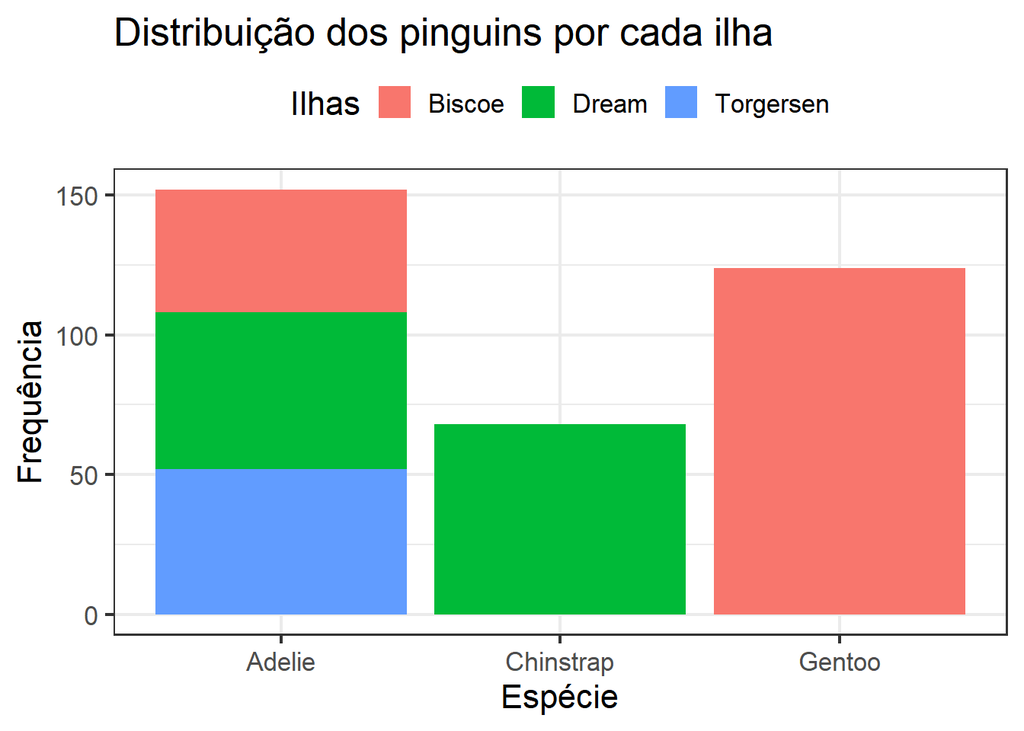

```r
ggplot(
  penguins,
  aes(x = species, fill = island)
) +
  geom_bar() +
  labs(
    title = "Distribuição dos pinguins por cada ilha",
    x = "Espécie",
    y = "Frequência",
    fill = "Ilhas"
  ) +
  theme_bw(16) +
  theme(
    legend.position = "top"
  )
```

### Gráfico de dispersão

E para o nosso segundo (e último) gráfico, vejamos a correlação entre os comprimentos (em mm) dos bicos e das barbatanas dos pinguins, colorindo cada ponto pela espécie a que pertencem.

Usaremos uma escala de cores que seja amigável para pessoas com daltonismo (“Emparelhado”)[^1]

**Código**

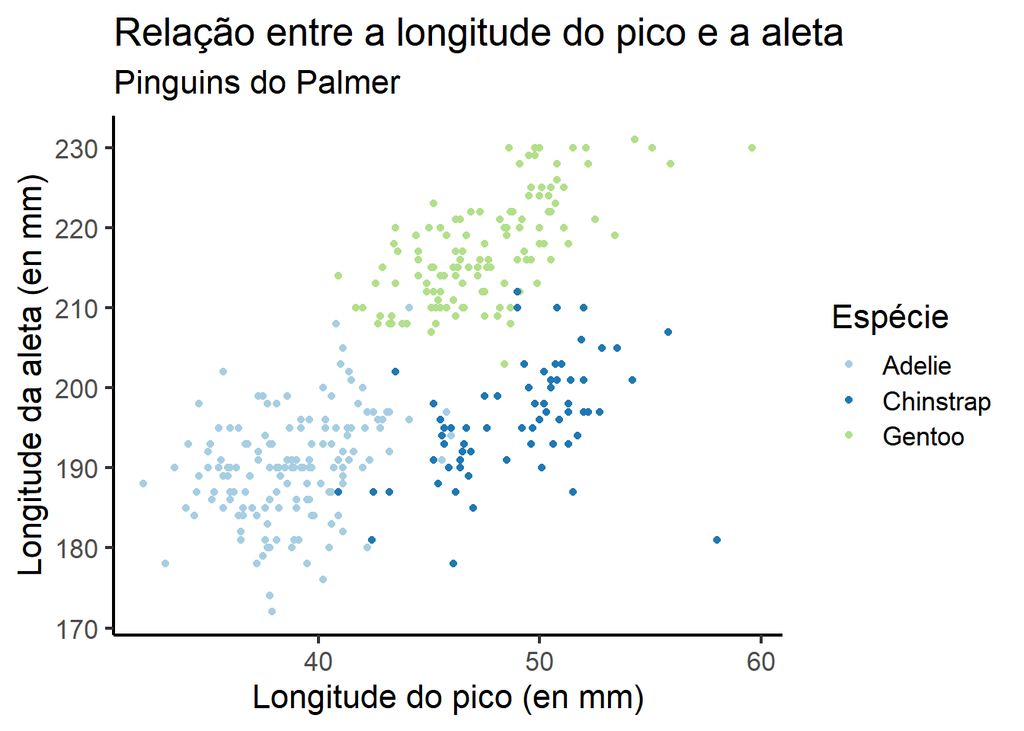

```r
ggplot(
  penguins,
  aes(x = bill_length_mm,
      y = flipper_length_mm,
      color = species)
) +
  geom_point() +
  scale_color_brewer(palette = "Paired") +
  labs(
    title = "Relação entre a longitude do pico e a aleta",
    subtitle = "Pinguins do Palmer",
    x = "Longitude do pico (en mm)",
    y = "Longitude da aleta (en mm)",
    color = "Espécie"
  ) +
  theme_classic(16)
```

## Notas de rodapé

[^1]: Outras escalas podem ser exploradas em https://colorbrewer2.org/